# Are ‘High Tax’ States Better Places to Live?

Pratyush Jha, Paul Atadja, Xinhao Wang

2025-12-09

# Introduction

This project explores whether U.S. states with higher tax collections per capita tend to be better places to live, as measured by the Human Development Index (HDI). This question is politically and socially relevant because of ongoing debates about “high-tax” versus “low-tax” states.

The analysis combines tax revenue data and HDI data from two separate sources; The Tax Foundation and UNData.

```r
# Import Tax Data
saltpc <- read_csv("saltpc.csv") %>%
rename(Tax_PC = `Collections per Capita`) %>%
filter(State != "United States")
```

```r
# Import State HDI Data

shdi <- read_csv("statesbyhdicv.csv") %>%
rename(HDI = Value)
```

```r
# Check column names, Join

colnames(saltpc)
```

```
## [1] "State"  "Tax_PC" "Rank"
```

```r
colnames(shdi)
```

```
## [1] "Rank"  "State" "HDI"
```

```r
state_df <- inner_join(saltpc, shdi, by = "State")
```

```r
# 'Tax_PC' was stored as a string, convert to numeric

state_df <- state_df %>%
mutate(Tax_PC = as.numeric(str_replace_all(Tax_PC, "[$,]", "")))
```

```r
# Save tidy dataset
write_csv(state_df, "tidy_state_tax_hdi.csv")
```

```r
# View merged
head(state_df)
```

```
## # A tibble: 6 × 5
##   State      Tax_PC Rank.x Rank.y   HDI
##   <chr>       <dbl>  <dbl>  <dbl> <dbl>
## 1 Alabama      4722     50     49 0.887
## 2 Alaska       6915     19     20 0.94
## 3 Arizona      5232     40     37 0.917
## 4 Arkansas     5289     37     47 0.89
## 5 California  10319      2     21 0.94
## 6 Colorado     7263     15      4 0.958
```

```r
#summary statistics table
summary_table <- state_df %>%
summarise(
Mean_Tax_PC = mean(Tax_PC, na.rm = TRUE),
SD_Tax_PC = sd(Tax_PC, na.rm = TRUE),
Min_Tax_PC = min(Tax_PC, na.rm = TRUE),
Max_Tax_PC = max(Tax_PC, na.rm = TRUE),
Mean_HDI = mean(HDI, na.rm = TRUE),
SD_HDI = sd(HDI, na.rm = TRUE),
Min_HDI = min(HDI, na.rm = TRUE),
Max_HDI = max(HDI, na.rm = TRUE)
)

knitr::kable(summary_table, caption = "Summary Statistics for Tax Revenue and HDI")
```

Summary Statistics for Tax Revenue and HDI

| Mean_Tax_PC | SD_Tax_PC | Min_Tax_PC | Max_Tax_PC | Mean_HDI | SD_HDI | Min_HDI | Max_HDI |
| --- | --- | --- | --- | --- | --- | --- | --- |
| 6838.49 | 2066.54 | 4722 | 14974 | 0.9295098 | 0.0234328 | 0.868 | 0.961 |

```r
# Correlation Test
cor_test <- cor.test(state_df$Tax_PC, state_df$HDI, method = "pearson")
cor_test
```

```
##
##  Pearson's product-moment correlation
##
## data:  state_df$Tax_PC and state_df$HDI
## t = 4.9194, df = 49, p-value = 1.019e-05
## alternative hypothesis: true correlation is not equal to 0
## 95 percent confidence interval:
##  0.3557733 0.7342242
## sample estimates:
##       cor
## 0.5749826
```

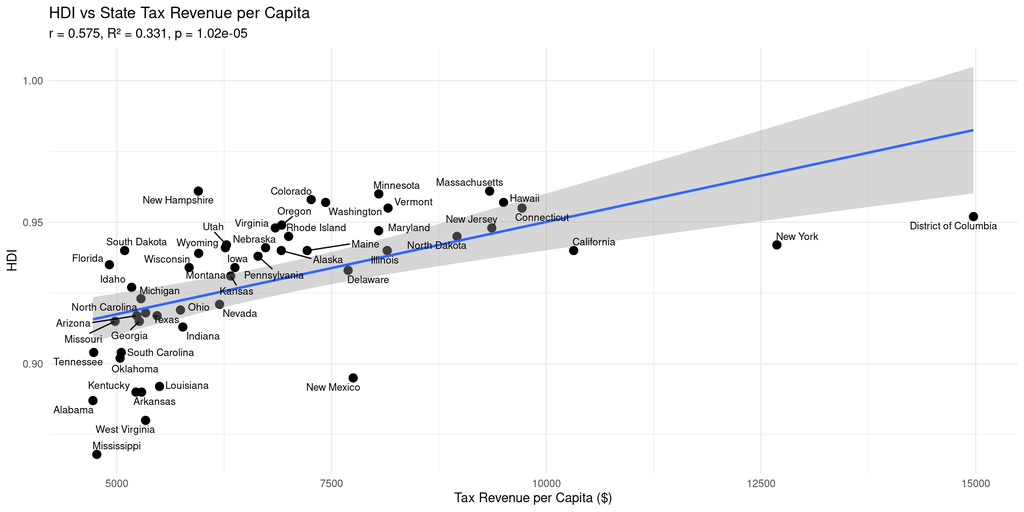

```r
# Scatterplot with Regression Line
model <- lm(HDI ~ Tax_PC, data = state_df)

r  <- round(cor(state_df$Tax_PC, state_df$HDI), 3)
r2 <- round(summary(model)$r.squared, 3)
p  <- signif(cor.test(state_df$Tax_PC, state_df$HDI)$p.value, 3)

ggplot(state_df, aes(x = Tax_PC, y = HDI, label = State)) +
  geom_point(size = 3) +
  geom_smooth(method = "lm", se = TRUE) +
  geom_text_repel(size = 3, max.overlaps = 20) +
  labs(
    title = "HDI vs State Tax Revenue per Capita",
    subtitle = paste0("r = ", r, ", R² = ", r2, ", p = ", p),
    x = "Tax Revenue per Capita ($)",
    y = "HDI"
  ) +
  theme_minimal()
```

## Limitations

Although there is a positive association, the analysis has some limitations

- Correlation is not causation, higher taxes doesn’t cause better quality of life
- Reverse causality may exist
- states with wealthier populations may collect higher taxes due to higher income
- Tax revenue doesn’t capture spending efficiency - two states may collect similar revenue but spends it differently
- HDI components evolve slowly and reflects on decades rather than current tax policy
- Factors not included such as healthcare access, education spending, cost of living and urbanization may also play major roles in determining HDI

## Discussion

The results show a moderate positive correlation (r ≈ 0.57) between state tax revenue per capita and HDI. This suggests that states which collect more taxes per person tend to have better overall quality-of-life outcomes. However, this does not imply causation. Higher HDI may lead to higher incomes and higher tax bases rather than the reverse. Additionally, other variables such as education spending, healthcare access, and urbanization likely play major roles.